# Module 8 Guide

GEOG-3440

This document describes the important concepts, workflows, functions, and other information useful for this week.

### Readings

- Finish reading **Vector data manipulation** in the [R-Spatial book](https://rspatial.org/spatial/7-vectmanip.html)
- Read the **Raster data** and **Raster Data Manipulation** sections in the [R-Spatial book](https://rspatial.org/spatial/8-rastermanip.html#)
- Finish up the section on *Spatial data with terra* in the book

### Main Goals

```
## terra 1.8.54
```

## **1. Combining Raster and Vector Data**

Digital elevation models (DEMs) are a form of digital raster data that represents elevation. This can be freely downloaded from multiple sites, including [USGS Earth Explorer](https://earthexplorer.usgs.gov/) site. Global datasets have been made available through remote sensing missions like the Shuttle Radar Topography Mission (SRTM). Elevation is typically displayed in a terrain color scale, though each pixel in the raster represents the ground elevation (typically in meters above sea level).

The `terra` packages comes with a DEM of Luxembourg, and we can use this in conjunction with vector data:

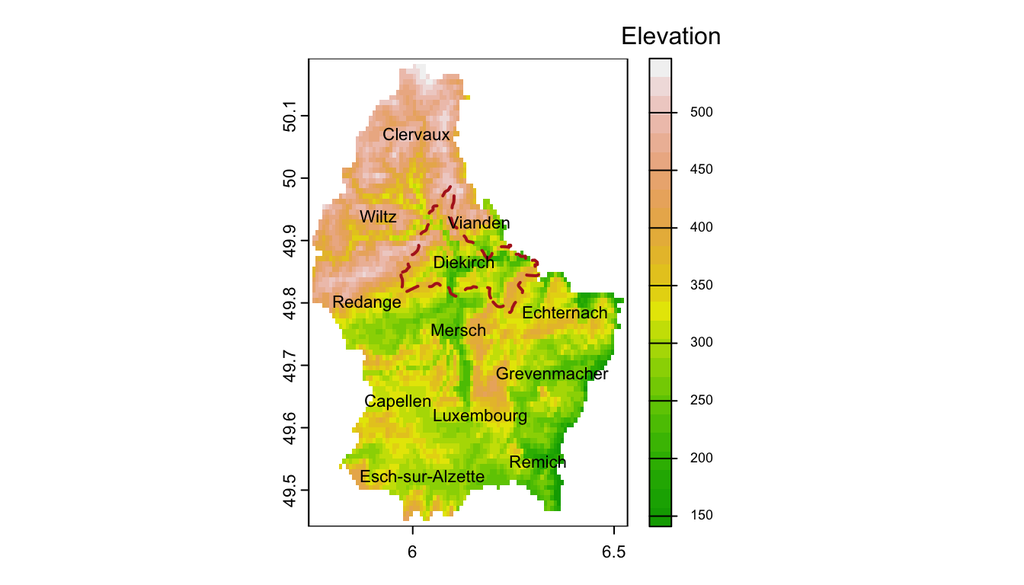

```r
filename <- system.file("ex/elev.tif", package="terra")
r <- rast(filename) # read in raster file
# plot(r, main="SpatRaster DEM of Luxembourg")
f <- system.file("ex/lux.shp", package="terra")
p <- vect(f) # read in vector file
plot(r, col = terrain.colors(25), plg=list(title="Elevation", cex=0.7, bty="o")) # plot
p_sub <- p[p$NAME_2=="Diekirch",] # only keep Diekirck
plot(p_sub, border='firebrick', lty=2, lwd=2, add=T)
text(p, "NAME_2", cex=0.7)
```

We can also extract or subset spatial datasets based on one another. The R-Spatial book goes into more detail about some of the high-level functions. Two you will likely use frequently are `crop` and `mask`, which will subset your raster based on a region (polygon):

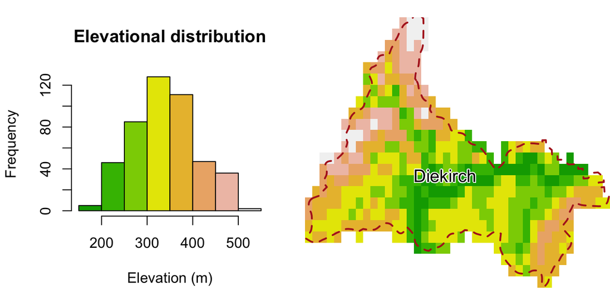

```r
r_crop <- crop(x = r, y = p_sub, mask = TRUE) # crop r to the extent of p_sub

par(mfrow=c(1,2))
h <-  hist(r_crop, breaks=9, col=terrain.colors(8), main="Elevational distribution", xlab="Elevation (m)") # create histogram of elevation
plot(r_crop, col=terrain.colors(8), axes=FALSE, mar=c(0,0,0,0)) # plot subset of r
plot(p_sub, border='firebrick', lty=2, lwd=2, add=T)
text(p_sub, "NAME_2", cex=1.2, halo=TRUE)
```

Point data can be used to `extract` values from another raster or vector dataset:

```r
# create point data from centroids of polygons
pts <- centroids(p)

# extract elevation values at each point
extract(r, pts)
```

```
##    ID elevation
## 1   1       444
## 2   2       295
## 3   3       382
## 4   4       404
## 5   5       414
## 6   6       320
## 7   7       193
## 8   8       228
## 9   9       313
## 10 10       282
## 11 11       328
## 12 12       221
```

The extracted data contains the same dimensions as the `pts`, which means this can be added as a new variable to the pts dataset with `$` or `cbind`.

Furthermore, you can calculate statistics based on the entire image (global):

```r
# global stats
e_mean <- global(r, na.rm=T)$mean
cat("The average elevation of Luxembourg is", round(e_mean, 2), "meters above sea level")
```

```
## The average elevation of Luxembourg is 348.34 meters above sea level
```

And individual areas (zonal):

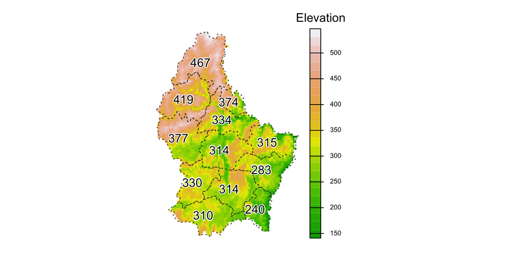

```r
# zonal stats
z <- zonal(r, p, fun="mean", na.rm=T, as.polygons=TRUE)
z$elevation <- round(z$elevation)

# plot
plot(r, col=terrain.colors(25), plg=list(title="Elevation", cex=0.7, bty="o", pos=4), mar=c(2,0,2,3.5), axes=F) # plot
legend("topleft", legend="Mean Elevation \nby Canton", bty="n") # add a description
plot(z, border='grey20', lty=3, lwd=1, add=T) # plot cantons
text(z, "elevation", halo=TRUE, adj=0.7) # add mean elevation by canton
```

The `zonal` function calculates a specified statistic from a raster (or vector) within a defined boundaries (typically a polygon). Zonal and global statistics provide incredibly useful summary statistics about regional information.

The `geodata` package, and several others, can also be used to access and download useful raster datasets for environmental and socioeconomic variables. Explore different datasets that are quickly accessible through [geodata](https://cran.r-project.org/web/packages/geodata/geodata.pdf).

**Complete the Module Task**